# STA437 Final Report

#### 4.2. Cluster Interpretation

To understand the meaning of each cluster, we examined the average CDS spread curves (PX1–PX10) for companies within each group. We computed the mean spread at each tenor within each cluster and visualized the average term structures.

##### 4.2.1. Average CDS Curves by Cluster

```r
# Code to summarize and plot average PX1–PX10 curves by cluster

#### Add Cluster Labels Back to the Data
cds_clustered <- cbind(cds_avg, Cluster = pca_df$Cluster)
```

##### 4.2.2. Summarize CDS Spreads by Cluster

```r
library(dplyr)
cluster_summary <- cds_clustered %>%
  group_by(Cluster) %>%
  summarise(across(starts_with("PX"), mean, .names = "avg_{.col}"))
print(cluster_summary)
```

```
## # A tibble: 3 × 11
##   Cluster avg_PX1 avg_PX2 avg_PX3 avg_PX4 avg_PX5 avg_PX6 avg_PX7 avg_PX8
##   <fct>     <dbl>   <dbl>   <dbl>   <dbl>   <dbl>   <dbl>   <dbl>   <dbl>
## 1 1          90.8   120.    152.    185.    216.    239.    255.    265.
## 2 2          18.7    28.3    39.6    52.9    66.1    77.9    86.5    92.6
## 3 3         917.    869.    893.    885.    885.    873.    866.    857.
## # ℹ 2 more variables: avg_PX9 <dbl>, avg_PX10 <dbl>
```

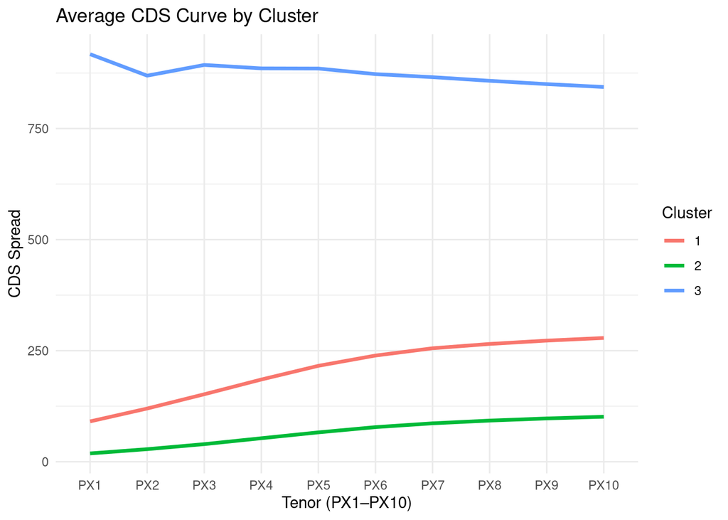

```r
library(reshape2)
cluster_long <- melt(cds_clustered, id.vars = "Cluster", measure.vars = paste0("PX", 1:10))

ggplot(cluster_long, aes(x = variable, y = value, group = Cluster, color = Cluster)) +
  stat_summary(fun = mean, geom = "line", linewidth = 1.2) +
  labs(title = "Average CDS Curve by Cluster",
       x = "Tenor (PX1–PX10)", y = "CDS Spread") +
  theme_minimal()
```

These results show that the clustering is meaningful and reflects clear differences in credit profiles across firms — both in terms of level and shape of the CDS term structure. This analysis motivates a deeper look at the relationships between CDS tenors, which we explore next using factor analysis.

## 5. Factor Analysis

To further investigate the structure of the CDS spread data, we applied factor analysis (FA) to the PX1–PX10 variables. This method identifies unobserved latent variables (“factors”) that explain correlations among the observed tenors. It provides a complementary view to PCA by focusing on the dependency structure rather than maximizing variance.

We fit a 2-factor model with varimax rotation to improve interpretability.

#### 5.1. Select PX Variables and Standardize

```r
cds_matrix <- cds_avg[, paste0("PX", 1:10)]
cds_scaled <- scale(cds_matrix)
```

#### 5.2. Run Factor Analysis with 2 factors

```r
fa_result <- factanal(cds_scaled, factors = 2, rotation = "varimax")
print(fa_result)
```

```
##
## Call:
## factanal(x = cds_scaled, factors = 2, rotation = "varimax")
##
## Uniquenesses:
##   PX1   PX2   PX3   PX4   PX5   PX6   PX7   PX8   PX9  PX10
## 0.024 0.005 0.005 0.005 0.005 0.005 0.005 0.005 0.005 0.005
##
## Loadings:
##      Factor1 Factor2
## PX1  0.424   0.892
## PX2  0.546   0.836
## PX3  0.642   0.765
## PX4  0.725   0.687
## PX5  0.788   0.614
## PX6  0.830   0.557
## PX7  0.856   0.517
## PX8  0.869   0.493
## PX9  0.880   0.474
## PX10 0.888   0.458
##
##                Factor1 Factor2
## SS loadings      5.776   4.183
## Proportion Var   0.578   0.418
## Cumulative Var   0.578   0.996
##
## Test of the hypothesis that 2 factors are sufficient.
## The chi square statistic is 17864.26 on 26 degrees of freedom.
## The p-value is 0
```

#### 5.3. Visualize Loadings

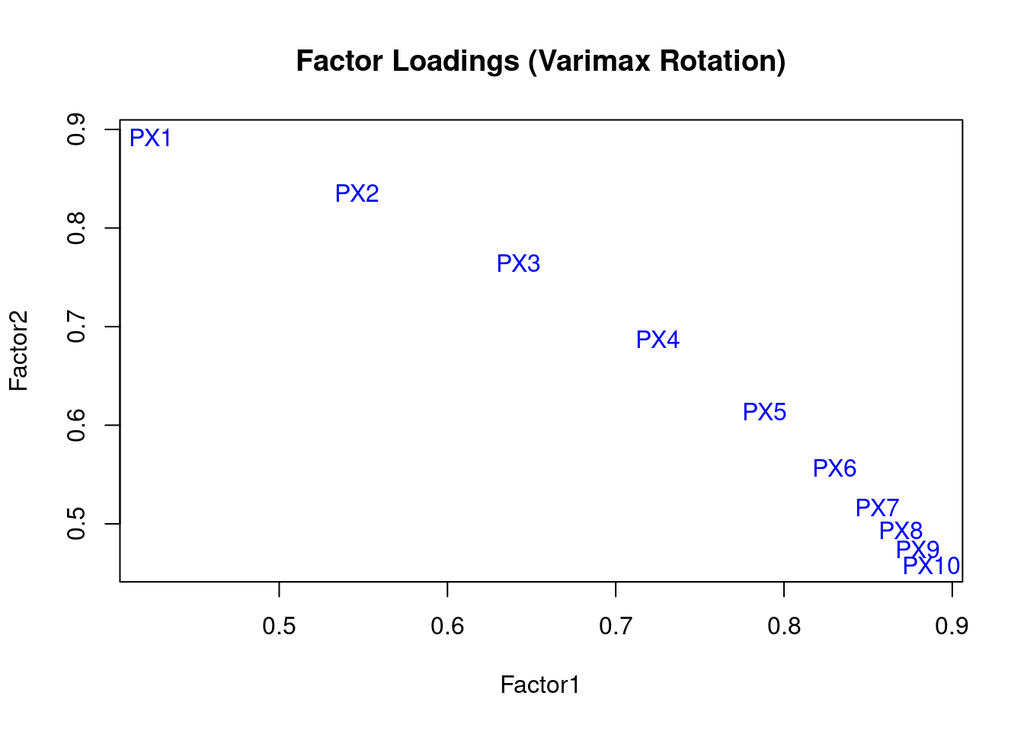

```r
# Code to plot factor loadings and label PX1–PX10
loadings <- fa_result$loadings[, 1:2]
plot(loadings, type = "n", main = "Factor Loadings (Varimax Rotation)")
text(loadings, labels = rownames(loadings), col = "blue")
abline(h = 0, v = 0, col = "gray", lty = 2)
```

The loadings plot shows a clear two-factor structure:

- Factor 1: Dominated by PX6–PX10, indicating it captures long-term credit risk.
- Factor 2: Driven by PX1–PX3, suggesting it reflects short-term risk sentiment.

This confirms that the CDS curve structure is driven by at least two interpretable latent factors — one affecting long maturities and another influencing short-term spreads. The results are consistent with financial theory and match the latent groupings we observed in PCA and clustering.

## 6. Conclusion

In this project, we used PCA, clustering, and factor analysis to explore patterns in CDS spreads across ten maturities for over 600 companies. PCA revealed that nearly all variation in the data is captured by the first two principal components, indicating that CDS term structures are highly redundant and dominated by a single risk dimension.

K-means clustering on the PCA-reduced space identified three distinct groups of companies with different credit risk profiles. These groups corresponded to firms with low, moderate, and high CDS spread levels and varying curve shapes. This shows that companies can be meaningfully categorized based on the structure of their credit default swaps.

Finally, factor analysis confirmed the presence of two underlying latent factors: one capturing long-term credit risk (driven by PX6–PX10), and one reflecting short-term risk sentiment (PX1–PX3). These results aligned with our clustering and PCA findings, reinforcing the interpretation that CDS curves are shaped by a small number of interpretable risk components.

Together, these multivariate methods provided a consistent view of the structure of CDS spreads and revealed key groupings and dependencies in the dataset.